# Lecture2_2024_Overview: In R

Katrina Bazemore, MPH

2024-08-29

This code was written based on Stata code provided by Dr. Justine Shults, using reference code written by Dr. Erin Schnellinger, and using ChatGPT. The outputs approximate outputs of the Stata code.

Set up

Loading necessary libraries

```r
library(dplyr)
library(ggplot2)
library(geepack)
library(gtsummary)

#if libraries not already installed, use <install.packages("dplyr")> replacing dplyr with the package name
```

Specifying file containing functions we will use

```r
source("../RCode/EPID6210-inR/functions.R")
#source("functions.R")
```

Read in the transplant data and view the first few observations

```r
bmi_data <- read.csv("bmiz_after_renal_transplant.csv")

head(bmi_data)
```

```
##   id month     bmiz obese
## 1  1     0 1.488681     0
## 2  1     1 1.563131     0
## 3  1     3 1.985113     1
## 4  1     6 2.021322     1
## 5  1    12 2.134451     1
## 6  1    24 1.937832     1
```

Summarize the variables

```r
bmi_data %>%
  tbl_summary(
    type = list(everything() ~ "continuous2"),
    statistic = list(all_continuous() ~ c("{mean} ({sd})",
                                          "{min}, {max}")),
    digits = all_continuous() ~ 2,) %>%
  add_n()
```

| **Characteristic** | **N** | **N = 631** |
| --- | --- | --- |
| id | 631 |  |
| Mean (SD) |  | 54.35 (33.56) |
| Min, Max |  | 1.00, 118.00 |
| month | 631 |  |
| Mean (SD) |  | 14.44 (19.28) |
| Min, Max |  | 0.00, 96.00 |
| bmiz | 631 |  |
| Mean (SD) |  | 0.84 (1.25) |
| Min, Max |  | -4.55, 3.31 |
| obese | 631 |  |
| Mean (SD) |  | 0.30 (0.46) |
| Min, Max |  | 0.00, 1.00 |

There are 631 measurements. How many subjects are there?

```r
length(unique(bmi_data$id))
```

```
## [1] 100
```

Descriptive data from lecture 1

```r
bmi_data %>%
  dplyr::group_by(month) %>%
  dplyr::summarise(Count = n(),
                   Mean=mean(bmiz, na.rm = T))
```

```
## # A tibble: 12 × 3
##    month Count   Mean
##    <int> <int>  <dbl>
##  1     0   100 0.0716
##  2     1    89 0.675
##  3     3    91 1.08
##  4     6    84 1.23
##  5    12    89 1.04
##  6    24    68 0.871
##  7    36    45 0.895
##  8    48    32 1.01
##  9    60    13 1.12
## 10    72    10 1.46
## 11    84     6 1.09
## 12    96     4 0.872
```

Display the first 10 rows of data

```r
bmi_data %>% arrange(id, month) %>% slice(1:10)
```

```
##    id month     bmiz obese
## 1   1     0 1.488681     0
## 2   1     1 1.563131     0
## 3   1     3 1.985113     1
## 4   1     6 2.021322     1
## 5   1    12 2.134451     1
## 6   1    24 1.937832     1
## 7   2     0 0.813134     0
## 8   2     1 1.328913     0
## 9   2     3 1.773646     1
## 10  2    12 2.057137     1
```

Regress bmiz on month and month-squared

```r
# Regress bmiz on month and month^2
model_bmiz <- lm(bmiz ~ month + I(month^2), data = bmi_data)
summary(model_bmiz)
```

```
##
## Call:
## lm(formula = bmiz ~ month + I(month^2), data = bmi_data)
##
## Residuals:
##     Min      1Q  Median      3Q     Max
## -5.2341 -0.8106  0.1050  0.9829  2.3161
##
## Coefficients:
##               Estimate Std. Error t value Pr(>|t|)
## (Intercept)  6.803e-01  7.048e-02   9.652  < 2e-16 ***
## month        1.855e-02  6.813e-03   2.723  0.00664 **
## I(month^2)  -1.796e-04  9.794e-05  -1.834  0.06712 .
## ---
## Signif. codes:  0 '***' 0.001 '**' 0.01 '*' 0.05 '.' 0.1 ' ' 1
##
## Residual standard error: 1.237 on 628 degrees of freedom
## Multiple R-squared:  0.01692,    Adjusted R-squared:  0.01379
## F-statistic: 5.405 on 2 and 628 DF,  p-value: 0.004705
```

```r
#Alternatively: summary(lm(bmiz ~ month + I(month^2), data = bmi_data))
#Can also obtain just the coefficients: summary(model_bmiz)$coefficients
```

Obtain and plot the fitted values form the regression model (R does not have a built in margins command, but the ChatGPT-generated code below seems to work. There is also a margins package (https://cran.r-project.org/web/packages/margins/vignettes/Introduction.html) that may replicate some of the functionality of the margins command)

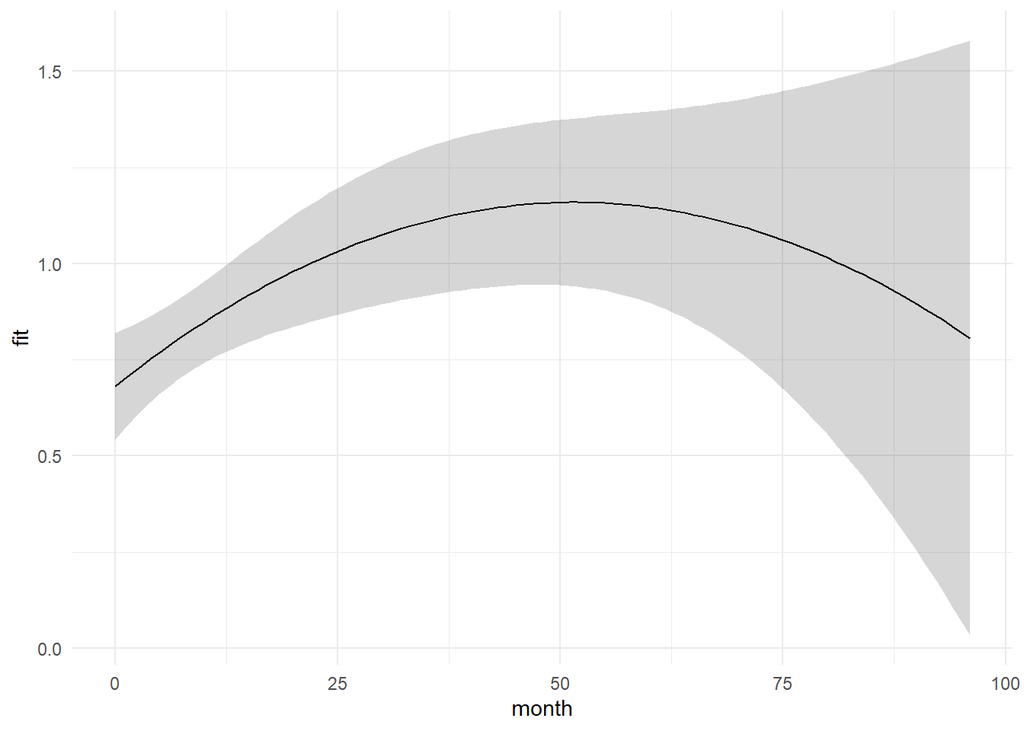

```r
margins <- predict(model_bmiz, newdata = data.frame(month = seq(min(bmi_data$month), max(bmi_data$month), by = 1)), interval = "confidence")

# Plotting margins
ggplot(data = data.frame(month = seq(min(bmi_data$month), max(bmi_data$month), by = 1), margins), aes(x = month, y = fit)) +
  geom_line() +
  geom_ribbon(aes(ymin = lwr, ymax = upr), alpha = 0.2) +
  theme_minimal()
```

```r
#Save plot as PDF
#ggsave("Lecture2_fittedvalues.png")
#This will save to your working directory
```

Evaluate time lags between consecutive measurements on subjects

```r
# Evaluate time lags between consecutive measurements on subjects
bmi_lag_data <- bmi_data %>%
  arrange(id, month) %>%
  group_by(id) %>%
  mutate(lag = month - lag(month, order_by = month))

#Estimate total lags (so we can calculate percents in the next step)
total_lags <- sum(table(bmi_lag_data$lag))

#Tabulate lag values
bmi_lag_data %>%
  dplyr::group_by(lag) %>%
  dplyr::summarise(Freq = n(),
                   Percent = ((n()/total_lags)*100)
                   )
```

```
## # A tibble: 12 × 3
##      lag  Freq Percent
##    <int> <int>   <dbl>
##  1     1    89  16.8
##  2     2    81  15.3
##  3     3    87  16.4
##  4     5     6   1.13
##  5     6    77  14.5
##  6     9    11   2.07
##  7    11     2   0.377
##  8    12   160  30.1
##  9    18     4   0.753
## 10    24    12   2.26
## 11    36     2   0.377
## 12    NA   100  18.8
```

```r
#Haven't yet figured out how to get the cumulative percent in the table
```

Information about the geeglm command

```r
help(geeglm)
```

Fit AR1 structure - using the gee package

```r
gee_arm <- gee::gee(bmiz ~ month + I(month^2), id = id, corstr = "AR-M", data = bmi_data)
```

```
## Beginning Cgee S-function, @(#) geeformula.q 4.13 98/01/27
```

```
## running glm to get initial regression estimate
```

```
##   (Intercept)         month    I(month^2)
##  0.6802840051  0.0185544733 -0.0001796267
```

```r
#Full model summary
#summary(gee_arm)

#Model coefficients
coeffs <- summary(gee_arm)$coefficients
    #Naive S.E is model-based
    #Robust S.E is sandwich-based

#To get a table with coefficients and p-values use the function P_table (from functions.R)
  #Specify the model and number of decimal places to round to
P_table(gee_arm, 4)
```

```
##             Estimate Naive S.E. Naive z Robust S.E. Robust z model_based_p
## (Intercept)   0.5315     0.1175  4.5241      0.1161   4.5779        0.0000
## month         0.0106     0.0062  1.7106      0.0043   2.4510        0.0872
## I(month^2)   -0.0001     0.0001 -1.4397      0.0001  -2.2864        0.1500
##             sandwich_based_p
## (Intercept)           0.0000
## month                 0.0142
## I(month^2)            0.0222
```

```r
#Display the estimated correlation matrix - two options for the gee package
  #Built in matrix
  gee_arm$working.correlation
```

```
##            [,1]      [,2]      [,3]      [,4]      [,5]      [,6]      [,7]
##  [1,] 1.0000000 0.8420595 0.7090643 0.5970743 0.5027722 0.4233641 0.3564978
##  [2,] 0.8420595 1.0000000 0.8420595 0.7090643 0.5970743 0.5027722 0.4233641
##  [3,] 0.7090643 0.8420595 1.0000000 0.8420595 0.7090643 0.5970743 0.5027722
##  [4,] 0.5970743 0.7090643 0.8420595 1.0000000 0.8420595 0.7090643 0.5970743
##  [5,] 0.5027722 0.5970743 0.7090643 0.8420595 1.0000000 0.8420595 0.7090643
##  [6,] 0.4233641 0.5027722 0.5970743 0.7090643 0.8420595 1.0000000 0.8420595
##  [7,] 0.3564978 0.4233641 0.5027722 0.5970743 0.7090643 0.8420595 1.0000000
##  [8,] 0.3001924 0.3564978 0.4233641 0.5027722 0.5970743 0.7090643 0.8420595
##  [9,] 0.2527798 0.3001924 0.3564978 0.4233641 0.5027722 0.5970743 0.7090643
## [10,] 0.2128557 0.2527798 0.3001924 0.3564978 0.4233641 0.5027722 0.5970743
## [11,] 0.1792372 0.2128557 0.2527798 0.3001924 0.3564978 0.4233641 0.5027722
## [12,] 0.1509284 0.1792372 0.2128557 0.2527798 0.3001924 0.3564978 0.4233641
##            [,8]      [,9]     [,10]     [,11]     [,12]
##  [1,] 0.3001924 0.2527798 0.2128557 0.1792372 0.1509284
##  [2,] 0.3564978 0.3001924 0.2527798 0.2128557 0.1792372
##  [3,] 0.4233641 0.3564978 0.3001924 0.2527798 0.2128557
##  [4,] 0.5027722 0.4233641 0.3564978 0.3001924 0.2527798
##  [5,] 0.5970743 0.5027722 0.4233641 0.3564978 0.3001924
##  [6,] 0.7090643 0.5970743 0.5027722 0.4233641 0.3564978
##  [7,] 0.8420595 0.7090643 0.5970743 0.5027722 0.4233641
##  [8,] 1.0000000 0.8420595 0.7090643 0.5970743 0.5027722
##  [9,] 0.8420595 1.0000000 0.8420595 0.7090643 0.5970743
## [10,] 0.7090643 0.8420595 1.0000000 0.8420595 0.7090643
## [11,] 0.5970743 0.7090643 0.8420595 1.0000000 0.8420595
## [12,] 0.5027722 0.5970743 0.7090643 0.8420595 1.0000000
```

```r
  #Matrix derived using function (from functions.R) - will have to use this function for models estimated with geepack
  createCorrelationMatrixR(gee_arm, model.corstr = "ar1", fitting.package = "gee")
```

```
##            t1        t2        t3        t4        t5        t6        t7
## t1  1.0000000 0.8420595 0.7090643 0.5970743 0.5027722 0.4233641 0.3564978
## t2  0.8420595 1.0000000 0.8420595 0.7090643 0.5970743 0.5027722 0.4233641
## t3  0.7090643 0.8420595 1.0000000 0.8420595 0.7090643 0.5970743 0.5027722
## t4  0.5970743 0.7090643 0.8420595 1.0000000 0.8420595 0.7090643 0.5970743
## t5  0.5027722 0.5970743 0.7090643 0.8420595 1.0000000 0.8420595 0.7090643
## t6  0.4233641 0.5027722 0.5970743 0.7090643 0.8420595 1.0000000 0.8420595
## t7  0.3564978 0.4233641 0.5027722 0.5970743 0.7090643 0.8420595 1.0000000
## t8  0.3001924 0.3564978 0.4233641 0.5027722 0.5970743 0.7090643 0.8420595
## t9  0.2527798 0.3001924 0.3564978 0.4233641 0.5027722 0.5970743 0.7090643
## t10 0.2128557 0.2527798 0.3001924 0.3564978 0.4233641 0.5027722 0.5970743
## t11 0.1792372 0.2128557 0.2527798 0.3001924 0.3564978 0.4233641 0.5027722
## t12 0.1509284 0.1792372 0.2128557 0.2527798 0.3001924 0.3564978 0.4233641
##            t8        t9       t10       t11       t12
## t1  0.3001924 0.2527798 0.2128557 0.1792372 0.1509284
## t2  0.3564978 0.3001924 0.2527798 0.2128557 0.1792372
## t3  0.4233641 0.3564978 0.3001924 0.2527798 0.2128557
## t4  0.5027722 0.4233641 0.3564978 0.3001924 0.2527798
## t5  0.5970743 0.5027722 0.4233641 0.3564978 0.3001924
## t6  0.7090643 0.5970743 0.5027722 0.4233641 0.3564978
## t7  0.8420595 0.7090643 0.5970743 0.5027722 0.4233641
## t8  1.0000000 0.8420595 0.7090643 0.5970743 0.5027722
## t9  0.8420595 1.0000000 0.8420595 0.7090643 0.5970743
## t10 0.7090643 0.8420595 1.0000000 0.8420595 0.7090643
## t11 0.5970743 0.7090643 0.8420595 1.0000000 0.8420595
## t12 0.5027722 0.5970743 0.7090643 0.8420595 1.0000000
```

Fit AR1 structure - using the geepack package Note: the default standard error estimate for geeglm (from geepack) is the robust estimate (https://cran.r-project.org/web/packages/geepack/geepack.pdf, page 7)

```r
# GEE with AR(1) structure & robust SE
gee_ar1 <- geeglm(bmiz ~ month + I(month^2), id = id, corstr = "ar1", data = bmi_data)
summary(gee_ar1)
```

```
##
## Call:
## geeglm(formula = bmiz ~ month + I(month^2), data = bmi_data,
##     id = id, corstr = "ar1")
##
##  Coefficients:
##               Estimate    Std.err   Wald Pr(>|W|)
## (Intercept)  5.187e-01  1.174e-01 19.531  9.9e-06 ***
## month        8.647e-03  4.337e-03  3.976   0.0461 *
## I(month^2)  -1.173e-04  5.178e-05  5.135   0.0235 *
## ---
## Signif. codes:  0 '***' 0.001 '**' 0.01 '*' 0.05 '.' 0.1 ' ' 1
##
## Correlation structure = ar1
## Estimated Scale Parameters:
##
##             Estimate Std.err
## (Intercept)    1.608  0.1814
##   Link = identity
##
## Estimated Correlation Parameters:
##       Estimate Std.err
## alpha   0.9012 0.02169
## Number of clusters:   100  Maximum cluster size: 12
```

```r
#Get more information on the model
gee_ar1$geese
```

```
##
## Call:
## geeglm(formula = bmiz ~ month + I(month^2), data = bmi_data,
##     id = id, corstr = "ar1")
##
## Mean Model:
##  Mean Link:                 identity
##  Variance to Mean Relation: gaussian
##
##  Coefficients:
## (Intercept)       month  I(month^2)
##   0.5186955   0.0086474  -0.0001173
##
## Scale Model:
##  Scale Link:                identity
##
##  Estimated Scale Parameters:
## (Intercept)
##       1.608
##
## Correlation Model:
##  Correlation Structure:     ar1
##  Correlation Link:          identity
##
##  Estimated Correlation Parameters:
##  alpha
## 0.9012
##
## Returned Error Value:  0
## Number of clusters:   100   Maximum cluster size: 12
```

```r
#Print just the alpha
gee_ar1$geese$alpha
```

```
##  alpha
## 0.9012
```

```r
#Display the estimated correlation matrix - not build in for geepack, have to use function from (functions.R)
createCorrelationMatrixR(gee_ar1, model.corstr = "ar1", fitting.package = "geepack")
```

```
##         t1     t2     t3     t4     t5     t6     t7     t8     t9    t10
## t1  1.0000 0.9012 0.8121 0.7318 0.6595 0.5943 0.5356 0.4827 0.4350 0.3920
## t2  0.9012 1.0000 0.9012 0.8121 0.7318 0.6595 0.5943 0.5356 0.4827 0.4350
## t3  0.8121 0.9012 1.0000 0.9012 0.8121 0.7318 0.6595 0.5943 0.5356 0.4827
## t4  0.7318 0.8121 0.9012 1.0000 0.9012 0.8121 0.7318 0.6595 0.5943 0.5356
## t5  0.6595 0.7318 0.8121 0.9012 1.0000 0.9012 0.8121 0.7318 0.6595 0.5943
## t6  0.5943 0.6595 0.7318 0.8121 0.9012 1.0000 0.9012 0.8121 0.7318 0.6595
## t7  0.5356 0.5943 0.6595 0.7318 0.8121 0.9012 1.0000 0.9012 0.8121 0.7318
## t8  0.4827 0.5356 0.5943 0.6595 0.7318 0.8121 0.9012 1.0000 0.9012 0.8121
## t9  0.4350 0.4827 0.5356 0.5943 0.6595 0.7318 0.8121 0.9012 1.0000 0.9012
## t10 0.3920 0.4350 0.4827 0.5356 0.5943 0.6595 0.7318 0.8121 0.9012 1.0000
## t11 0.3532 0.3920 0.4350 0.4827 0.5356 0.5943 0.6595 0.7318 0.8121 0.9012
## t12 0.3183 0.3532 0.3920 0.4350 0.4827 0.5356 0.5943 0.6595 0.7318 0.8121
##        t11    t12
## t1  0.3532 0.3183
## t2  0.3920 0.3532
## t3  0.4350 0.3920
## t4  0.4827 0.4350
## t5  0.5356 0.4827
## t6  0.5943 0.5356
## t7  0.6595 0.5943
## t8  0.7318 0.6595
## t9  0.8121 0.7318
## t10 0.9012 0.8121
## t11 1.0000 0.9012
## t12 0.9012 1.0000
```

Fit exchangeable structure - using the gee package

```r
gee_exch <- gee::gee(bmiz ~ month + I(month^2), id = id, corstr = "exchangeable", data = bmi_data)
```

```
## Beginning Cgee S-function, @(#) geeformula.q 4.13 98/01/27
```

```
## running glm to get initial regression estimate
```

```
## (Intercept)       month  I(month^2)
##   0.6802840   0.0185545  -0.0001796
```

```r
summary(gee_exch)
```

```
##
##  GEE:  GENERALIZED LINEAR MODELS FOR DEPENDENT DATA
##  gee S-function, version 4.13 modified 98/01/27 (1998)
##
## Model:
##  Link:                      Identity
##  Variance to Mean Relation: Gaussian
##  Correlation Structure:     Exchangeable
##
## Call:
## gee::gee(formula = bmiz ~ month + I(month^2), id = id, data = bmi_data,
##     corstr = "exchangeable")
##
## Summary of Residuals:
##     Min      1Q  Median      3Q     Max
## -5.2598 -0.7595  0.1409  1.0005  2.4571
##
##
## Coefficients:
##               Estimate Naive S.E. Naive z Robust S.E. Robust z
## (Intercept)  0.7059408  0.1116541   6.323   1.103e-01    6.398
## month        0.0163598  0.0038226   4.280   4.797e-03    3.411
## I(month^2)  -0.0002278  0.0000556  -4.097   7.061e-05   -3.226
##
## Estimated Scale Parameter:  1.541
## Number of Iterations:  2
##
## Working Correlation
##         [,1]   [,2]   [,3]   [,4]   [,5]   [,6]   [,7]   [,8]   [,9]  [,10]
##  [1,] 1.0000 0.7143 0.7143 0.7143 0.7143 0.7143 0.7143 0.7143 0.7143 0.7143
##  [2,] 0.7143 1.0000 0.7143 0.7143 0.7143 0.7143 0.7143 0.7143 0.7143 0.7143
##  [3,] 0.7143 0.7143 1.0000 0.7143 0.7143 0.7143 0.7143 0.7143 0.7143 0.7143
##  [4,] 0.7143 0.7143 0.7143 1.0000 0.7143 0.7143 0.7143 0.7143 0.7143 0.7143
##  [5,] 0.7143 0.7143 0.7143 0.7143 1.0000 0.7143 0.7143 0.7143 0.7143 0.7143
##  [6,] 0.7143 0.7143 0.7143 0.7143 0.7143 1.0000 0.7143 0.7143 0.7143 0.7143
##  [7,] 0.7143 0.7143 0.7143 0.7143 0.7143 0.7143 1.0000 0.7143 0.7143 0.7143
##  [8,] 0.7143 0.7143 0.7143 0.7143 0.7143 0.7143 0.7143 1.0000 0.7143 0.7143
##  [9,] 0.7143 0.7143 0.7143 0.7143 0.7143 0.7143 0.7143 0.7143 1.0000 0.7143
## [10,] 0.7143 0.7143 0.7143 0.7143 0.7143 0.7143 0.7143 0.7143 0.7143 1.0000
## [11,] 0.7143 0.7143 0.7143 0.7143 0.7143 0.7143 0.7143 0.7143 0.7143 0.7143
## [12,] 0.7143 0.7143 0.7143 0.7143 0.7143 0.7143 0.7143 0.7143 0.7143 0.7143
##        [,11]  [,12]
##  [1,] 0.7143 0.7143
##  [2,] 0.7143 0.7143
##  [3,] 0.7143 0.7143
##  [4,] 0.7143 0.7143
##  [5,] 0.7143 0.7143
##  [6,] 0.7143 0.7143
##  [7,] 0.7143 0.7143
##  [8,] 0.7143 0.7143
##  [9,] 0.7143 0.7143
## [10,] 0.7143 0.7143
## [11,] 1.0000 0.7143
## [12,] 0.7143 1.0000
```

```r
P_table(gee_exch, 4)
```

```
##             Estimate Naive S.E. Naive z Robust S.E. Robust z model_based_p
## (Intercept)   0.7059     0.1117   6.323      0.1103    6.398             0
## month         0.0164     0.0038   4.280      0.0048    3.411             0
## I(month^2)   -0.0002     0.0001  -4.098      0.0001   -3.226             0
##             sandwich_based_p
## (Intercept)           0.0000
## month                 0.0006
## I(month^2)            0.0013
```

Fit exchangeable structure - using the geepack package Again, this defaults to robust SE estimation

```r
#GEE with exchangeable structure
gee_exc <- geeglm(bmiz ~ month + I(month^2), id = id, corstr = "exchangeable", data = bmi_data)
summary(gee_exc)
```

```
##
## Call:
## geeglm(formula = bmiz ~ month + I(month^2), data = bmi_data,
##     id = id, corstr = "exchangeable")
##
##  Coefficients:
##              Estimate   Std.err Wald Pr(>|W|)
## (Intercept)  7.06e-01  1.10e-01 40.9  1.6e-10 ***
## month        1.64e-02  4.80e-03 11.6  0.00065 ***
## I(month^2)  -2.28e-04  7.06e-05 10.4  0.00125 **
## ---
## Signif. codes:  0 '***' 0.001 '**' 0.01 '*' 0.05 '.' 0.1 ' ' 1
##
## Correlation structure = exchangeable
## Estimated Scale Parameters:
##
##             Estimate Std.err
## (Intercept)     1.53   0.178
##   Link = identity
##
## Estimated Correlation Parameters:
##       Estimate Std.err
## alpha    0.717  0.0491
## Number of clusters:   100  Maximum cluster size: 12
```

```r
createCorrelationMatrixR(gee_exc, model.corstr = "exchangeable", fitting.package = "geepack")
```

```
##        t1    t2    t3    t4    t5    t6    t7    t8    t9   t10   t11   t12
## t1  1.000 0.717 0.717 0.717 0.717 0.717 0.717 0.717 0.717 0.717 0.717 0.717
## t2  0.717 1.000 0.717 0.717 0.717 0.717 0.717 0.717 0.717 0.717 0.717 0.717
## t3  0.717 0.717 1.000 0.717 0.717 0.717 0.717 0.717 0.717 0.717 0.717 0.717
## t4  0.717 0.717 0.717 1.000 0.717 0.717 0.717 0.717 0.717 0.717 0.717 0.717
## t5  0.717 0.717 0.717 0.717 1.000 0.717 0.717 0.717 0.717 0.717 0.717 0.717
## t6  0.717 0.717 0.717 0.717 0.717 1.000 0.717 0.717 0.717 0.717 0.717 0.717
## t7  0.717 0.717 0.717 0.717 0.717 0.717 1.000 0.717 0.717 0.717 0.717 0.717
## t8  0.717 0.717 0.717 0.717 0.717 0.717 0.717 1.000 0.717 0.717 0.717 0.717
## t9  0.717 0.717 0.717 0.717 0.717 0.717 0.717 0.717 1.000 0.717 0.717 0.717
## t10 0.717 0.717 0.717 0.717 0.717 0.717 0.717 0.717 0.717 1.000 0.717 0.717
## t11 0.717 0.717 0.717 0.717 0.717 0.717 0.717 0.717 0.717 0.717 1.000 0.717
## t12 0.717 0.717 0.717 0.717 0.717 0.717 0.717 0.717 0.717 0.717 0.717 1.000
```

```r
#Got slightly different estimated correlation structures between the two packages
```

GEE with tri-diagonal structure: neither package has an option for a tri-diagonal correlation structure

Fit unstructured structure - using the GEE package

```r
gee_unstruc <- gee::gee(bmiz ~ month + I(month^2), id = id, corstr = "unstructured", data = bmi_data)
```

```
## Beginning Cgee S-function, @(#) geeformula.q 4.13 98/01/27
```

```
## running glm to get initial regression estimate
```

```
## (Intercept)       month  I(month^2)
##     0.68028     0.01855    -0.00018
```

```r
summary(gee_unstruc)
```

```
##
##  GEE:  GENERALIZED LINEAR MODELS FOR DEPENDENT DATA
##  gee S-function, version 4.13 modified 98/01/27 (1998)
##
## Model:
##  Link:                      Identity
##  Variance to Mean Relation: Gaussian
##  Correlation Structure:     Unstructured
##
## Call:
## gee::gee(formula = bmiz ~ month + I(month^2), id = id, data = bmi_data,
##     corstr = "unstructured")
##
## Summary of Residuals:
##    Min     1Q Median     3Q    Max
## -5.069 -0.755  0.166  1.032  2.448
##
##
## Coefficients:
##              Estimate Naive S.E. Naive z Robust S.E. Robust z
## (Intercept)  0.515594   1.12e-01    4.62    1.15e-01     4.49
## month        0.032973   5.64e-03    5.84    5.08e-03     6.49
## I(month^2)  -0.000349   8.55e-05   -4.08    7.37e-05    -4.74
##
## Estimated Scale Parameter:  1.54
## Number of Iterations:  5
##
## Working Correlation
##            [,1]     [,2]     [,3]     [,4]      [,5]      [,6]      [,7]
##  [1,]  1.000000 0.763239 5.94e-01 0.572904  0.654707  0.553363  0.490730
##  [2,]  0.763239 1.000000 7.97e-01 0.686979  0.606357  0.463439  0.366672
##  [3,]  0.594192 0.797130 1.00e+00 0.821551  0.664951  0.416927  0.322516
##  [4,]  0.572904 0.686979 8.22e-01 1.000000  0.684905  0.414888  0.293976
##  [5,]  0.654707 0.606357 6.65e-01 0.684905  1.000000  0.590423  0.441735
##  [6,]  0.553363 0.463439 4.17e-01 0.414888  0.590423  1.000000  0.553998
##  [7,]  0.490730 0.366672 3.23e-01 0.293976  0.441735  0.553998  1.000000
##  [8,]  0.130607 0.056931 8.10e-02 0.061211  0.150890  0.182109  0.187454
##  [9,] -0.026385 0.004801 3.15e-02 0.008502  0.042771  0.066297  0.062506
## [10,] -0.016747 0.016545 4.20e-02 0.022240  0.033647  0.046563  0.042976
## [11,]  0.001495 0.002301 1.69e-03 0.001421  0.000362 -0.000796 -0.000378
## [12,] -0.000113 0.000259 2.65e-05 0.000136 -0.000202 -0.000322 -0.000143
##            [,8]      [,9]     [,10]     [,11]     [,12]
##  [1,]  0.130607 -2.64e-02 -1.67e-02  1.50e-03 -1.13e-04
##  [2,]  0.056931  4.80e-03  1.65e-02  2.30e-03  2.59e-04
##  [3,]  0.080962  3.15e-02  4.20e-02  1.69e-03  2.65e-05
##  [4,]  0.061211  8.50e-03  2.22e-02  1.42e-03  1.36e-04
##  [5,]  0.150890  4.28e-02  3.36e-02  3.62e-04 -2.02e-04
##  [6,]  0.182109  6.63e-02  4.66e-02 -7.96e-04 -3.22e-04
##  [7,]  0.187454  6.25e-02  4.30e-02 -3.78e-04 -1.43e-04
##  [8,]  1.000000  6.75e-02  4.80e-02 -2.61e-04 -1.63e-04
##  [9,]  0.067459  1.00e+00  6.03e-02 -1.08e-03 -7.04e-05
## [10,]  0.048015  6.03e-02  1.00e+00 -4.66e-04  6.42e-05
## [11,] -0.000261 -1.08e-03 -4.66e-04  1.00e+00  4.27e-05
## [12,] -0.000163 -7.04e-05  6.42e-05  4.27e-05  1.00e+00
```

```r
P_table(gee_unstruc, 4)
```

```
##             Estimate Naive S.E. Naive z Robust S.E. Robust z model_based_p
## (Intercept)   0.5156     0.1115    4.62      0.1147     4.49             0
## month         0.0330     0.0056    5.84      0.0051     6.49             0
## I(month^2)   -0.0003     0.0001   -4.08      0.0001    -4.74             0
##             sandwich_based_p
## (Intercept)                0
## month                      0
## I(month^2)                 0
```

```r
gee_unstruc$error
```

```
## [1] 0
```

```r
#No errors reported

gee_unstruc$iterations
```

```
## [1] 5
```

```r
#I think this model was able to converge after 5 iterations
```

Fit unstructured structure - using the geepack package (default = robust SE)

```r
gee_unstr <- geeglm(bmiz ~ month + I(month^2), id = id, corstr = "unstructured", data = bmi_data)
summary(gee_unstr)
```

```
##
## Call:
## geeglm(formula = bmiz ~ month + I(month^2), data = bmi_data,
##     id = id, corstr = "unstructured")
##
##  Coefficients:
##              Estimate   Std.err  Wald Pr(>|W|)
## (Intercept)  2.005908  0.157545 162.1  < 2e-16 ***
## month       -0.093168  0.014415  41.8  1.0e-10 ***
## I(month^2)   0.001124  0.000229  24.0  9.5e-07 ***
## ---
## Signif. codes:  0 '***' 0.001 '**' 0.01 '*' 0.05 '.' 0.1 ' ' 1
##
## Correlation structure = unstructured
## Estimated Scale Parameters:
##
##             Estimate Std.err
## (Intercept)     2.45   0.269
##   Link = identity
##
## Estimated Correlation Parameters:
##             Estimate Std.err
## alpha.1:2    1.40254  0.0760
## alpha.1:3    0.89983  0.0674
## alpha.1:4    0.57928  0.0969
## alpha.1:5    0.40547  0.1314
## alpha.1:6    0.07460  0.2048
## alpha.1:7    0.09805  0.2796
## alpha.1:8   -0.09305  0.2130
## alpha.1:9   -0.18421  0.2297
## alpha.1:10   0.19243  0.3090
## alpha.1:11   0.27222  0.8359
## alpha.1:12   2.11553  1.0627
## alpha.2:3    0.72408  0.0387
## alpha.2:4    0.50263  0.0579
## alpha.2:5    0.40776  0.0771
## alpha.2:6    0.25635  0.1283
## alpha.2:7    0.28680  0.1855
## alpha.2:8    0.03159  0.1400
## alpha.2:9   -0.11347  0.1776
```

[output cut: 34 more lines]

```
## alpha.7:9    0.39470  0.1755
## alpha.7:10   0.12827  0.4620
## alpha.7:11  -0.78357  0.8293
## alpha.7:12  -0.90205  1.1692
## alpha.8:9    0.52252  0.1883
## alpha.8:10   0.32400  0.4741
## alpha.8:11  -0.88558  0.8482
## alpha.8:12  -0.87531  1.1444
## alpha.9:10   0.88910  0.4293
## alpha.9:11   0.43769  0.8280
## alpha.9:12  -0.69494  1.1003
## alpha.10:11  1.06082  1.1014
## alpha.10:12 -0.14489  1.0857
## alpha.11:12  1.39484  1.3250
## Number of clusters:   100  Maximum cluster size: 12
```

```r
#I think the long list of estimated parameters is telling us there was a failure to converge

gee_unstr$geese$alpha
```

```
##   alpha.1:2   alpha.1:3   alpha.1:4   alpha.1:5   alpha.1:6   alpha.1:7
##     1.40254     0.89983     0.57928     0.40547     0.07460     0.09805
##   alpha.1:8   alpha.1:9  alpha.1:10  alpha.1:11  alpha.1:12   alpha.2:3
##    -0.09305    -0.18421     0.19243     0.27222     2.11553     0.72408
##   alpha.2:4   alpha.2:5   alpha.2:6   alpha.2:7   alpha.2:8   alpha.2:9
##     0.50263     0.40776     0.25635     0.28680     0.03159    -0.11347
##  alpha.2:10  alpha.2:11  alpha.2:12   alpha.3:4   alpha.3:5   alpha.3:6
##     0.00427    -0.10264     0.80727     0.50221     0.47265     0.38543
##   alpha.3:7   alpha.3:8   alpha.3:9  alpha.3:10  alpha.3:11  alpha.3:12
##     0.44998     0.25509     0.07629     0.13835    -0.06451     1.24846
##   alpha.4:5   alpha.4:6   alpha.4:7   alpha.4:8   alpha.4:9  alpha.4:10
##     0.51746     0.47721     0.51450     0.25227    -0.03887    -0.09967
##  alpha.4:11  alpha.4:12   alpha.5:6   alpha.5:7   alpha.5:8   alpha.5:9
##    -0.12252     0.50550     0.66280     0.68852     0.40945     0.09845
##  alpha.5:10  alpha.5:11  alpha.5:12   alpha.6:7   alpha.6:8   alpha.6:9
##    -0.01430    -0.16813     0.85510     0.89300     0.49280     0.22309
##  alpha.6:10  alpha.6:11  alpha.6:12   alpha.7:8   alpha.7:9  alpha.7:10
##     0.04264    -0.26552     0.19178     0.61401     0.39470     0.12827
##  alpha.7:11  alpha.7:12   alpha.8:9  alpha.8:10  alpha.8:11  alpha.8:12
##    -0.78357    -0.90205     0.52252     0.32400    -0.88558    -0.87531
##  alpha.9:10  alpha.9:11  alpha.9:12 alpha.10:11 alpha.10:12 alpha.11:12
##     0.88910     0.43769    -0.69494     1.06082    -0.14489     1.39484
```

```r
#Even though the model did not converge, this function will still output a correlation matrix, but we have many values outside 0-1
createCorrelationMatrixR(gee_unstr, model.corstr = "unstructured", fitting.package = "geepack")
```

```
##          t1       t2      t3      t4      t5      t6     t7      t8      t9
## t1   1.0000  1.40254  0.8998  0.5793  0.4055  0.0746  0.098 -0.0930 -0.1842
## t2   1.4025  1.00000  0.7241  0.5026  0.4078  0.2564  0.287  0.0316 -0.1135
## t3   0.8998  0.72408  1.0000  0.5022  0.4727  0.3854  0.450  0.2551  0.0763
## t4   0.5793  0.50263  0.5022  1.0000  0.5175  0.4772  0.514  0.2523 -0.0389
## t5   0.4055  0.40776  0.4727  0.5175  1.0000  0.6628  0.689  0.4094  0.0985
## t6   0.0746  0.25635  0.3854  0.4772  0.6628  1.0000  0.893  0.4928  0.2231
## t7   0.0980  0.28680  0.4500  0.5145  0.6885  0.8930  1.000  0.6140  0.3947
## t8  -0.0930  0.03159  0.2551  0.2523  0.4094  0.4928  0.614  1.0000  0.5225
## t9  -0.1842 -0.11347  0.0763 -0.0389  0.0985  0.2231  0.395  0.5225  1.0000
## t10  0.1924  0.00427  0.1384 -0.0997 -0.0143  0.0426  0.128  0.3240  0.8891
## t11  0.2722 -0.10264 -0.0645 -0.1225 -0.1681 -0.2655 -0.784 -0.8856  0.4377
## t12  2.1155  0.80727  1.2485  0.5055  0.8551  0.1918 -0.902 -0.8753 -0.6949
##          t10     t11    t12
## t1   0.19243  0.2722  2.116
## t2   0.00427 -0.1026  0.807
## t3   0.13835 -0.0645  1.248
## t4  -0.09967 -0.1225  0.505
## t5  -0.01430 -0.1681  0.855
## t6   0.04264 -0.2655  0.192
## t7   0.12827 -0.7836 -0.902
## t8   0.32400 -0.8856 -0.875
## t9   0.88910  0.4377 -0.695
## t10  1.00000  1.0608 -0.145
## t11  1.06082  1.0000  1.395
## t12 -0.14489  1.3948  1.000
```

Fitting identity structure - using the GEE package

```r
gee_ident <- gee::gee(bmiz ~ month + I(month^2), id = id, corstr = "independence", data = bmi_data)
```

```
## Beginning Cgee S-function, @(#) geeformula.q 4.13 98/01/27
```

```
## running glm to get initial regression estimate
```

```
## (Intercept)       month  I(month^2)
##     0.68028     0.01855    -0.00018
```

```r
summary(gee_ident)
```

```
##
##  GEE:  GENERALIZED LINEAR MODELS FOR DEPENDENT DATA
##  gee S-function, version 4.13 modified 98/01/27 (1998)
##
## Model:
##  Link:                      Identity
##  Variance to Mean Relation: Gaussian
##  Correlation Structure:     Independent
##
## Call:
## gee::gee(formula = bmiz ~ month + I(month^2), id = id, data = bmi_data,
##     corstr = "independence")
##
## Summary of Residuals:
##    Min     1Q Median     3Q    Max
## -5.234 -0.811  0.105  0.983  2.316
##
##
## Coefficients:
##             Estimate Naive S.E. Naive z Robust S.E. Robust z
## (Intercept)  0.68028   7.05e-02    9.65    1.12e-01     6.06
## month        0.01855   6.81e-03    2.72    6.20e-03     2.99
## I(month^2)  -0.00018   9.79e-05   -1.83    9.17e-05    -1.96
##
## Estimated Scale Parameter:  1.53
## Number of Iterations:  1
##
## Working Correlation
##       [,1] [,2] [,3] [,4] [,5] [,6] [,7] [,8] [,9] [,10] [,11] [,12]
##  [1,]    1    0    0    0    0    0    0    0    0     0     0     0
##  [2,]    0    1    0    0    0    0    0    0    0     0     0     0
##  [3,]    0    0    1    0    0    0    0    0    0     0     0     0
##  [4,]    0    0    0    1    0    0    0    0    0     0     0     0
##  [5,]    0    0    0    0    1    0    0    0    0     0     0     0
##  [6,]    0    0    0    0    0    1    0    0    0     0     0     0
##  [7,]    0    0    0    0    0    0    1    0    0     0     0     0
##  [8,]    0    0    0    0    0    0    0    1    0     0     0     0
##  [9,]    0    0    0    0    0    0    0    0    1     0     0     0
## [10,]    0    0    0    0    0    0    0    0    0     1     0     0
## [11,]    0    0    0    0    0    0    0    0    0     0     1     0
## [12,]    0    0    0    0    0    0    0    0    0     0     0     1
```

```r
P_table(gee_ident, 4)
```

```
##             Estimate Naive S.E. Naive z Robust S.E. Robust z model_based_p
## (Intercept)   0.6803     0.0705    9.65      0.1123     6.06        0.0000
## month         0.0186     0.0068    2.72      0.0062     2.99        0.0065
## I(month^2)   -0.0002     0.0001   -1.83      0.0001    -1.96        0.0666
##             sandwich_based_p
## (Intercept)           0.0000
## month                 0.0028
## I(month^2)            0.0502
```

Fitting identity structure - using the geepack package (default = robust SE)

```r
gee_id <- geeglm(bmiz ~ month + I(month^2), id = id, corstr = "independence", data = bmi_data)
summary(gee_id)
```

```
##
## Call:
## geeglm(formula = bmiz ~ month + I(month^2), data = bmi_data,
##     id = id, corstr = "independence")
##
##  Coefficients:
##              Estimate   Std.err  Wald Pr(>|W|)
## (Intercept)  6.80e-01  1.12e-01 36.70  1.4e-09 ***
## month        1.86e-02  6.20e-03  8.96   0.0028 **
## I(month^2)  -1.80e-04  9.17e-05  3.84   0.0502 .
## ---
## Signif. codes:  0 '***' 0.001 '**' 0.01 '*' 0.05 '.' 0.1 ' ' 1
##
## Correlation structure = independence
## Estimated Scale Parameters:
##
##             Estimate Std.err
## (Intercept)     1.52   0.176
## Number of clusters:   100  Maximum cluster size: 12
```

```r
createCorrelationMatrixR(gee_id, model.corstr = "independent", fitting.package = "geepack")
```

```
##     t1 t2 t3 t4 t5 t6 t7 t8 t9 t10 t11 t12
## t1   1  0  0  0  0  0  0  0  0   0   0   0
## t2   0  1  0  0  0  0  0  0  0   0   0   0
## t3   0  0  1  0  0  0  0  0  0   0   0   0
## t4   0  0  0  1  0  0  0  0  0   0   0   0
## t5   0  0  0  0  1  0  0  0  0   0   0   0
## t6   0  0  0  0  0  1  0  0  0   0   0   0
## t7   0  0  0  0  0  0  1  0  0   0   0   0
## t8   0  0  0  0  0  0  0  1  0   0   0   0
## t9   0  0  0  0  0  0  0  0  1   0   0   0
## t10  0  0  0  0  0  0  0  0  0   1   0   0
## t11  0  0  0  0  0  0  0  0  0   0   1   0
## t12  0  0  0  0  0  0  0  0  0   0   0   1
```